# BASIC R FOR SOCIAL SCIENCES

Nhung Nguyen

2023-06-02

# R, R studio and R Markdown

- **R**: is a programming language, it allows to do many different tasks
- **R studio**: is a layout that you can code R and do everything you do in R. You can also code Python, Bash, or SQL.
- **R markdown**: is an interface between coder and R studio.

# What R can do

- Web-design
- Creating presentations
- Statistical analysis
- Text analysis
- Machine learning

…and more!!!

# Fundamental elements of R

- Packages (e.g. “tidyverse”, install.packages(“package_name”))
- Library (e.g. library(“package_name”))
- Functions (e.g. summary(data))
- Arguments (e.g. select(data, column_name))
- Code chunk and Notes

#```{r}

#```

#this is a note

## ***RStudio won’t run notes but it will run anything in a codechunk

# What will we learn?

- Structure of data management
- Statistic in R
- Data Wrangling
- Visualization
- Text mining in R

# Data organization and management

- RMarkdown - GoogleColab - VSCode - Quatro
- Directory
- Project
- Input files: (csv, photos, logos etc.))
- Format files (texts)
- Output files: RMarkdown files, Html files, PDF, Words.
- Saving and Knitting

# Elements of Data

- Dataframes, vectors, tibbles, strings, etc.
- Name variables
- Object

# Data Wrangling1

- Pipeline mutate( %>% / |> ) and mutate()
- Reform columns (e.g. as.character(), as.factors())
- Rename columns (e.g. rename(new_column = old_column))
- Recode values in variables (x <- recode(x, `3` = 10, `4` = 20))
- Summary()
- Missing data (e.g. is.na(df$column_name), is.na(df), summary())

# Data Wrangling2

- Pivot longer (e.g. df_long <- pivot_longer( df, cols = .., names_to = …, values_to = …)
- Pivot wider (e.g. df_wide <- pivot_wider( df, names_from = …, values_from = …)
- Join data (left_join, right_join, inner_join, full_join)
- Groups and Count (e.g.table(df$variable),

df %>% group_by(variable1, variable2) %>% summarize(count = n())

# Visualization of data and models

```r
#install.packages("ggplot2")
library(ggplot2)
```

- Histogram
- Boxplot
- Barplot
- Scatte plot and more…@

# Histogram

```r
# Generate random data
data <- rnorm(1000)
# Convert data to a data frame
df <- data.frame(data = data)
# Create a histogram using ggplot2
plot1 <- ggplot(df, aes(x = data)) +
  geom_histogram(fill = "steelblue", bins = 30) +
  labs(title = "Histogram", x = "Data", y = "Frequency")
# Save plot1 as a PNG file
ggsave("plot1.png", plot1, dpi = 250)
```

# Histogram

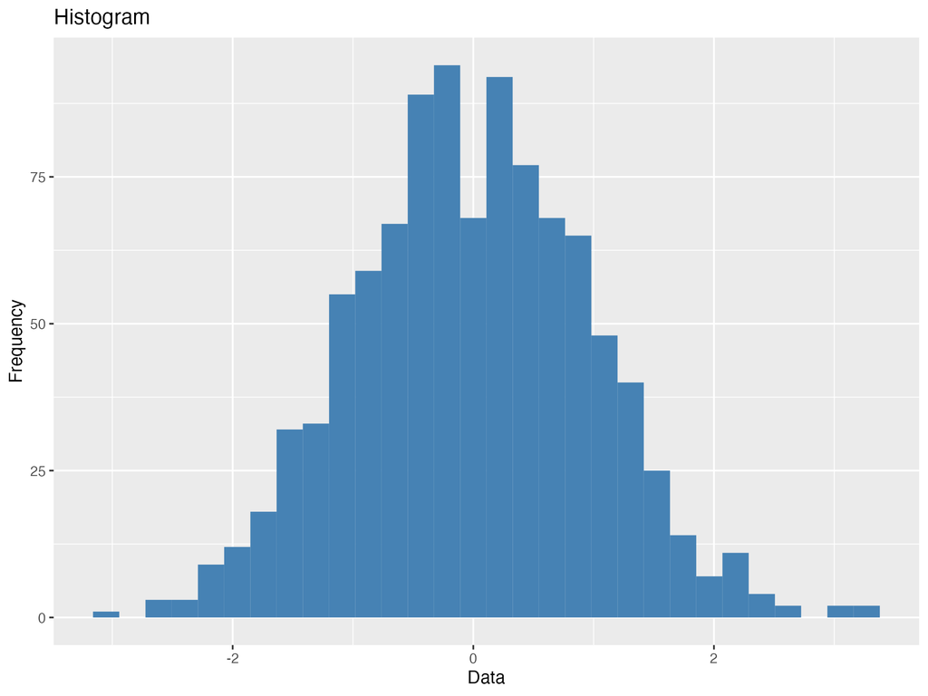

# - Boxplot

```r
# Set seed for reproducibility
set.seed(123)
# Generate random data
data1 <- rnorm(100)
data2 <- rnorm(100)
data3 <- rnorm(100)
data4 <- rnorm(100)
data5 <- rnorm(100)
# Create a data frame with all the random data
df2 <- data.frame(
  Group = rep(c("Group 1", "Group 2", "Group 3", "Group 4", "Group 5"), each = 100),
  Data = c(data1, data2, data3, data4, data5))
# Create a grouped boxplot using ggplot2
plot2 <- ggplot(df2, aes(x = Group, y = Data)) +
  geom_boxplot(width = 0.5, outlier.shape = NA, fill = "steelblue") +
  labs(title = "Grouped Boxplot", x = "Group", y = "Data") +
  theme_minimal()
# Save plotplo2 as a PNG file
ggsave("plot2.png", plot2, dpi = 250)
```

# boxplot

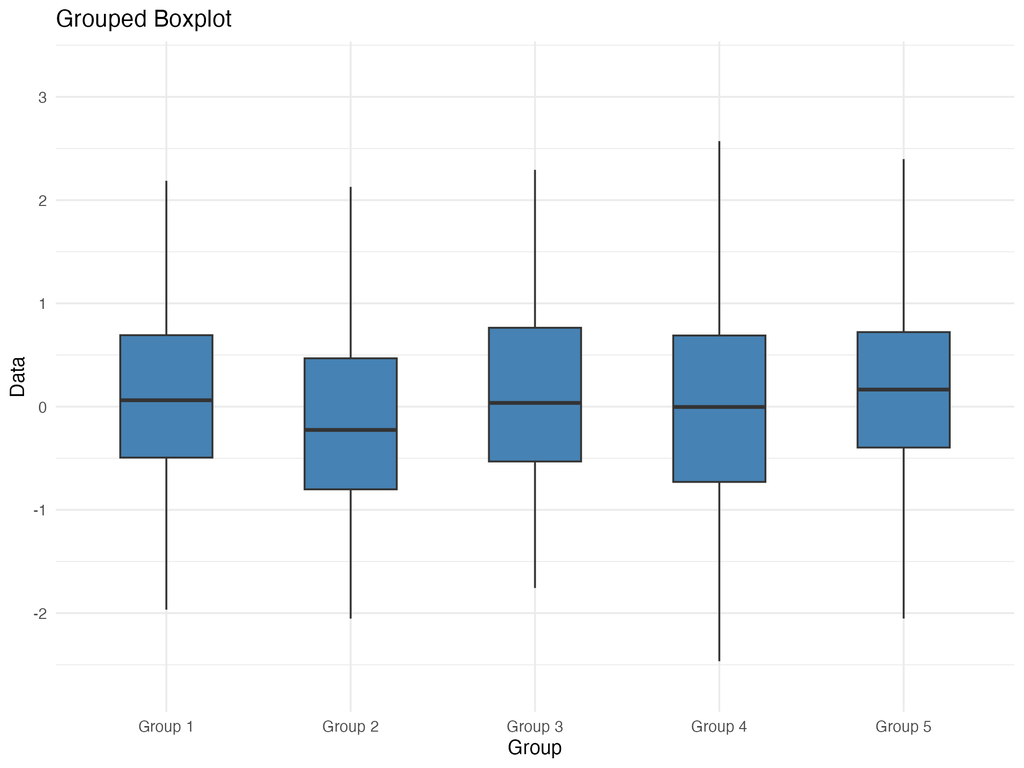

# Bar-gram

```r
# Sample data
x <- c("A", "B", "C", "D")
y <- c(10, 15, 7, 12)
data2 <- data.frame(Category = x, Value = y)
# Create bar plot using ggplot2
plot3 <- ggplot(data2, aes(x = Category, y = Value)) +
  geom_bar(stat = "identity", fill = "blue") +
  labs(title = "Bar Plot Example", x = "Categories", y = "Values")
# Save plot3 as a PNG file
ggsave("plot3.png", plot3, dpi = 250)
```

# Bar-gram

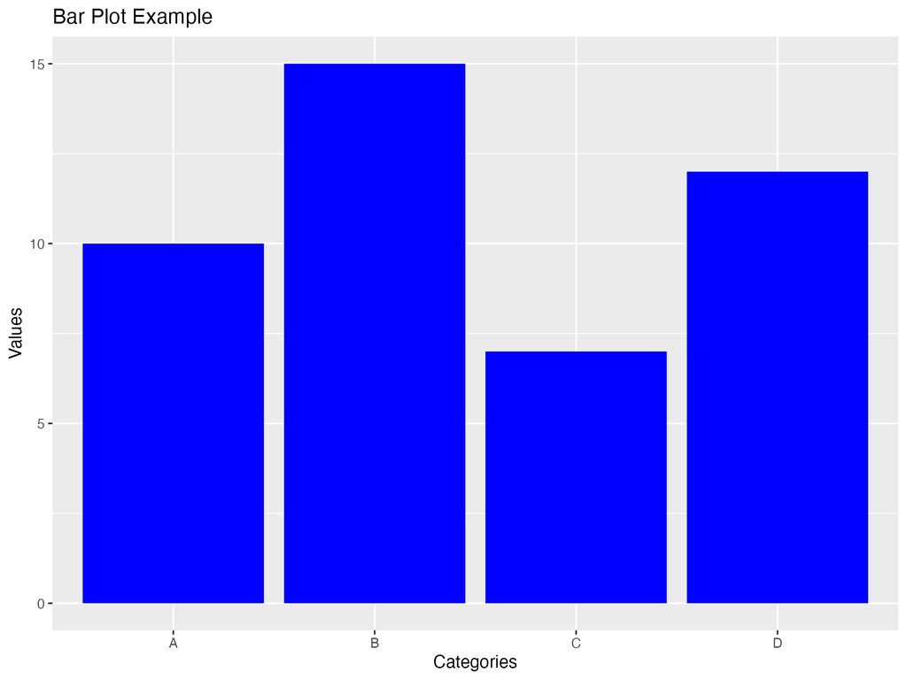

[output not shown]

# Scatter plot

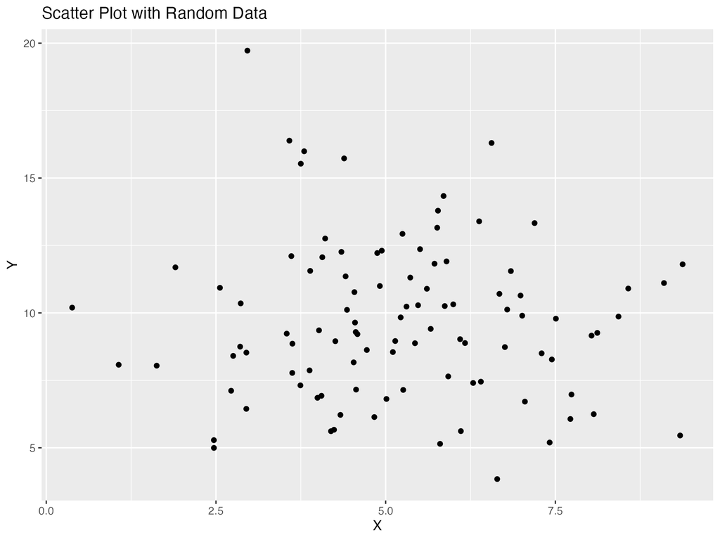

# Q&A and PRACTICE

# Thank you for your attention!!!